# The caret package

Statistical Learning Course

21 de abril, 2021

# Introduction

The caret package, short for **classification and regression training**, was built with several goals in mind:

- create a unified interface for modeling and prediction (interfaces to more than 200 models),
- to develop a set of semi-automated, reasonable approaches for optimizing the values of the tuning parameters for many of these models and
- increase computational efficiency using parallel processing

For more details:

Website/detailed help pages: http://caret.r-forge.r-project.org

JSS Paper: http://www.jstatsoft.org/v28/i05/paper

Applied Predictive Modeling Blog: http://appliedpredictivemodeling.com/

Caret cheatsheet in Rstudio cheatsheet page: https://www.rstudio.com/resources/cheatsheets/

# Example guide & create train/test sets

Sonar data from the `mlbench` package will be used.

- 208 data points collected on 60 predictors (energy within a particular frequency band).
- The goal is to predict two classes:
  - `M` for metal cylinder
  - `R` for rock

First, we the data into two groups: a **training set** and **a test set**. To do this, the `createDataPartition` function is used:

```r
if(!require("caret")) install.packages("caret")
if(!require("mlbench")) install.packages("mlbench")
library("caret")
library("mlbench")
```

```r
data(Sonar)
names(Sonar)
```

```
 [1] "V1"    "V2"    "V3"    "V4"    "V5"    "V6"    "V7"    "V8"    "V9"    "V10"   "V11"   "V12"
[13] "V13"   "V14"   "V15"   "V16"   "V17"   "V18"   "V19"   "V20"   "V21"   "V22"   "V23"   "V24"
[25] "V25"   "V26"   "V27"   "V28"   "V29"   "V30"   "V31"   "V32"   "V33"   "V34"   "V35"   "V36"
[37] "V37"   "V38"   "V39"   "V40"   "V41"   "V42"   "V43"   "V44"   "V45"   "V46"   "V47"   "V48"
[49] "V49"   "V50"   "V51"   "V52"   "V53"   "V54"   "V55"   "V56"   "V57"   "V58"   "V59"   "V60"
[61] "Class"
```

```r
set.seed(1234) # Control of data generation
inTrain <- createDataPartition(y=Sonar$Class, p=.75, list=FALSE)
str(inTrain)
```

```
 int [1:157, 1] 2 3 4 6 7 8 9 11 14 15 ...
 - attr(*, "dimnames")=List of 2
  ..$ : NULL
  ..$ : chr "Resample1"
```

```r
training <- Sonar[inTrain,]
testing <- Sonar[-inTrain,]
nrow(training)
```

```
[1] 157
```

Others similar functions are: `createFolds` & `createResample`

# Train function

Second, we tune a model, for example the Classification and Regression Trees based (CART) using the method = `rpart1SE`. This CART model replicates the same process used by the `rpart` function where the model complexity is determined using the one-standard error method. The `train` function can be used:

```r
CART1Model <- train (Class ~ .,
                   data=training,
                   method="rpart1SE",
                   preProc=c("center","scale"))
CART1Model
```

```
CART

157 samples
 60 predictor
  2 classes: 'M', 'R'

Pre-processing: centered (60), scaled (60)
Resampling: Bootstrapped (25 reps)
Summary of sample sizes: 157, 157, 157, 157, 157, 157, ...
Resampling results:

  Accuracy   Kappa
  0.6752493  0.350363
```

Note:

- `preProc` argument does un preprocess before to apply the model.
- By default, the *bootstrap* is used to obtain the estimation error.

The `trainControl` function controls the type of resampling used in the train process. We will have the function use three repeats of 10-fold (by default) cross-validation.

```r
ctrl <- trainControl(method = "repeatedcv", repeats=3)
CART1Model3x10cv <- train (Class ~ .,
                         data=training,
                         method="rpart1SE",
                         trControl=ctrl,
                         preProc=c("center","scale"))

CART1Model3x10cv
```

```
CART

157 samples
 60 predictor
  2 classes: 'M', 'R'

Pre-processing: centered (60), scaled (60)
Resampling: Cross-Validated (10 fold, repeated 3 times)
Summary of sample sizes: 141, 142, 142, 141, 141, 142, ...
Resampling results:

  Accuracy   Kappa
  0.7087173  0.4168066
```

# TrainControl function

Additional arguments are given to `trainControl`:

- `summaryFunctions` estimate some measure of performance:
  - `defaultSummary`
  - `twoClassSummary`
    - `classProbs = TRUE` option is used to computed the predicted class probabilities (which are not computed automatically).

In `train` function needs to indicate the custom performance measures with `metric` option.

```r
ctrl <- trainControl(method = "repeatedcv", repeats=3, classProbs=TRUE,
summaryFunction=twoClassSummary)
CART1Model3x10cv <- train (Class ~ .,
                         data=training,
                         method="rpart1SE",
                         trControl=ctrl,
                         metric="ROC",
                         preProc=c("center","scale"))

CART1Model3x10cv
```

```
CART

157 samples
 60 predictor
  2 classes: 'M', 'R'

Pre-processing: centered (60), scaled (60)
Resampling: Cross-Validated (10 fold, repeated 3 times)
Summary of sample sizes: 141, 141, 142, 141, 141, 142, ...
Resampling results:

  ROC        Sens   Spec
  0.7757068  0.775  0.6869048
```

# Others methods and models

In http://topepo.github.io/caret/bytag.html you can find everyone models that `caret` can be applied.

Now, a CART model using the `rpart` method will be tuned over the value of complexity parameter (cp) that should be used.

```r
CART2Fit3x10cv <- train (Class ~ .,
                       data=training,
                       method="rpart",
                       trControl=ctrl,
                       metric="ROC",
                       preProc=c("center","scale"))
CART2Fit3x10cv
```

```
CART

157 samples
 60 predictor
  2 classes: 'M', 'R'

Pre-processing: centered (60), scaled (60)
Resampling: Cross-Validated (10 fold, repeated 3 times)
Summary of sample sizes: 142, 142, 142, 142, 142, 140, ...
Resampling results across tuning parameters:

  cp          ROC        Sens       Spec
  0.06849315  0.7033441  0.6851852  0.6779762
  0.10958904  0.6829282  0.7523148  0.5922619
  0.47945205  0.5517196  0.8629630  0.2404762

ROC was used to select the optimal model using the largest value.
The final value used for the model was cp = 0.06849315.
```

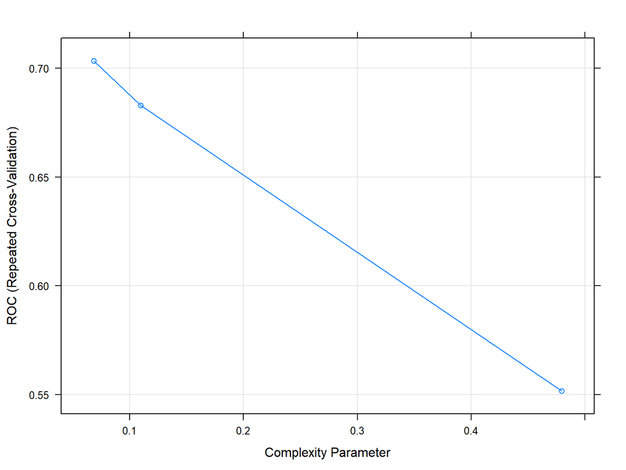

```r
plot(CART2Fit3x10cv)
```

```r
CART2Fit3x10cv <- train (Class ~ .,
                       data=training,
                       method="rpart",
                       trControl=ctrl,
                       metric="ROC",
                       tuneLength=10,
                       preProc=c("center","scale"))
CART2Fit3x10cv
```

```
CART

157 samples
 60 predictor
  2 classes: 'M', 'R'

Pre-processing: centered (60), scaled (60)
Resampling: Cross-Validated (10 fold, repeated 3 times)
Summary of sample sizes: 141, 142, 140, 141, 141, 142, ...
Resampling results across tuning parameters:

  cp          ROC        Sens       Spec
  0.00000000  0.7375744  0.7305556  0.6220238
  0.05327245  0.7382523  0.7453704  0.6130952
  0.10654490  0.6816468  0.7773148  0.5696429
  0.15981735  0.6787368  0.8092593  0.5482143
  0.21308980  0.6787368  0.8092593  0.5482143
  0.26636225  0.6787368  0.8092593  0.5482143
  0.31963470  0.6787368  0.8092593  0.5482143
  0.37290715  0.6787368  0.8092593  0.5482143
  0.42617960  0.6787368  0.8092593  0.5482143
  0.47945205  0.5748016  0.8680556  0.2815476

ROC was used to select the optimal model using the largest value.
The final value used for the model was cp = 0.05327245.
```

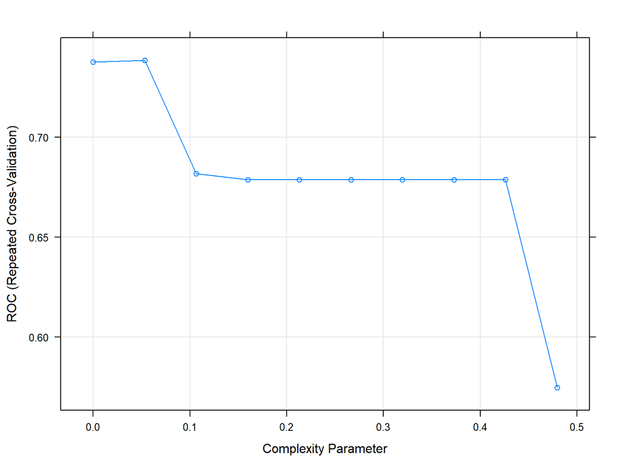

```r
plot(CART2Fit3x10cv)
```

Note: `tuneLength` argument is used to choose the values of the tune.

# Predict & confusionMatrix functions

To predict new samples can be used `predict` function.

- `type = prob` : to compute class probabilities
- `type = raw` : to predict the class

With `confusionMatrix` function will compute the confusion matrix and associated statistics for the model fit.

```r
CART2Probs <- predict(CART2Fit3x10cv, newdata = testing, type = "prob")
CART2Classes <- predict(CART2Fit3x10cv, newdata = testing, type = "raw")
confusionMatrix(data=CART2Classes,testing$Class)
```

```
Confusion Matrix and Statistics

          Reference
Prediction  M  R
         M 21  5
         R  6 19

               Accuracy : 0.7843
                 95% CI : (0.6468, 0.8871)
    No Information Rate : 0.5294
    P-Value [Acc > NIR] : 0.0001502

                  Kappa : 0.5681

 Mcnemar's Test P-Value : 1.0000000

            Sensitivity : 0.7778
            Specificity : 0.7917
         Pos Pred Value : 0.8077
         Neg Pred Value : 0.7600
             Prevalence : 0.5294
         Detection Rate : 0.4118
   Detection Prevalence : 0.5098
      Balanced Accuracy : 0.7847

       'Positive' Class : M
```

# Comparation of the models

The `resamples` function can be used to collect, summarize and contrast the resampling results.

```r
resamps=resamples(list(CART2=CART2Fit3x10cv,CART1=CART1Model3x10cv))
summary(resamps)
```

```
Call:
summary.resamples(object = resamps)

Models: CART2, CART1
Number of resamples: 30

ROC
           Min.   1st Qu.    Median      Mean   3rd Qu.     Max. NA's
CART2 0.5000000 0.6294643 0.7455357 0.7382523 0.8058036 0.952381    0
CART1 0.5535714 0.7249504 0.7926587 0.7757068 0.8315972 0.937500    0

Sens
           Min.   1st Qu.    Median      Mean 3rd Qu. Max. NA's
CART2 0.4444444 0.6250000 0.7500000 0.7453704   0.875    1    0
CART1 0.4444444 0.6666667 0.7777778 0.7750000   0.875    1    0

Spec
       Min.   1st Qu.    Median      Mean   3rd Qu.      Max. NA's
CART2 0.250 0.5714286 0.6250000 0.6130952 0.7142857 0.8750000    0
CART1 0.375 0.5714286 0.7142857 0.6869048 0.8571429 0.8571429    0
```

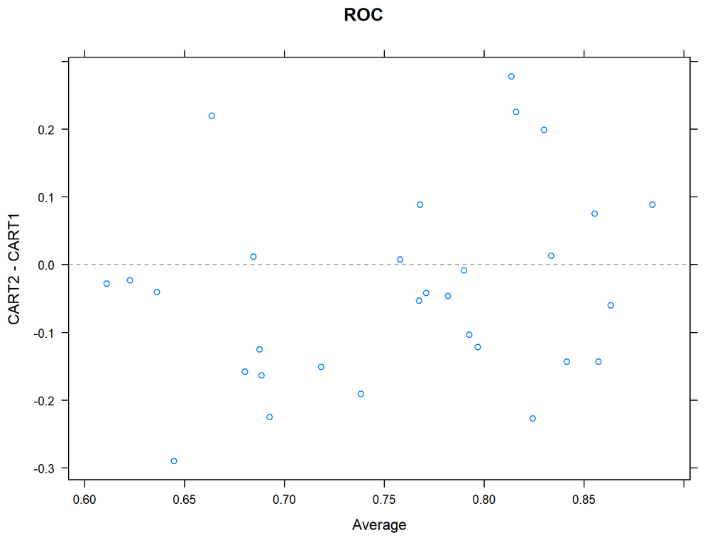

```r
xyplot(resamps,what="BlandAltman")
```

```r
diffs<-diff(resamps)
summary(diffs)
```

```
Call:
summary.diff.resamples(object = diffs)

p-value adjustment: bonferroni
Upper diagonal: estimates of the difference
Lower diagonal: p-value for H0: difference = 0

ROC
      CART2  CART1
CART2        -0.03745
CART1 0.1598

Sens
      CART2  CART1
CART2        -0.02963
CART1 0.4514

Spec
      CART2   CART1
CART2         -0.07381
CART1 0.02404
```

# Train Process

One of the primary tools in the package is the train function which can be used to

- evaluate, using resampling, the efect of model tuning parameters on performance
- choose the “optimal” model across these parameters
- estimate model performance from a training set

More formally:

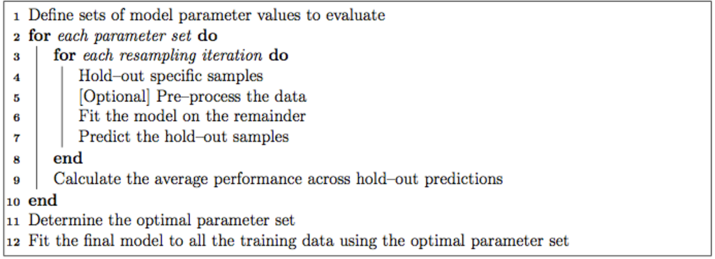

# Estimating Performance

To have an honest estimation of performance of the model cannot be obtained by predicting the same samples that were used to train the model. A test set and/or resampling can provide good estimates.

For regression models:

- $R^2$ is very popular. In many complex models, the notion of the model degrees of freedom is difficult. Unadjusted $R^2$ can be used, but does not penalize complexity. (`caret::Rsquared`)
- the root mean square error is a common metric for understanding the performance (`caret::RMSE`)
- Spearman’s correlation may be applicable for models that are used to rank samples (`cor(, method = "spearman")`)

For classification models:

- **confusion matrix** is a cross-tabulation of the observed and predicted classes.
- **overall accuracy** can be used, but this may be problematic when the classes are not balanced.
- the **Kappa statistic** takes into account the expected error rate:

$$\kappa= \frac{O-E}{1-E}$$

where *O* is the observed accuracy and *E* is the expected accuracy under chance agreement.

- For 2-class models:
  - **Receiver Operating Characteristic** (ROC) curves can be used to characterize model performance.
  - **Sensitivity** given that a result is truly an event, what is the probability that the model will predict an event results?
  - **Specificity** given that a result is truly not an event, what is the probability that the model will predict a negative results?